# Calculating distances within a layer

You for a set of features, you can calculate a variable that indicates the difference to the closest feature within the dataset.

# Required packages

This example uses the following packages

```r
library(tidyverse)
library(sf)
library(here)
library(leaflet)
library(knitr)
```

# Load some sample data

I’ll demonstrate this with a layer of transit stop locations (`stops`) in San Luis Obispo County, California.

```r
leaflet() %>%
  addProviderTiles(provider = providers$Stamen.TerrainBackground) %>%
  addCircleMarkers(data = stops,
                   radius = 2,
                   stroke = FALSE,
                   fillColor = "darkorange",
                   fillOpacity = 1)
```

[interactive chart not shown]

# Transform the data

If I want to calculate distances, my data need to be stored in a projected coordinate system (with coordinates in units of distance).

I’ll use the California State Plane, zone V (https://spatialreference.org/ref/esri/102645/), which stores coordinates in units of feet.

```r
# Define CA-state-plane
CA_st_plane <- "+proj=lcc +lat_1=34.03333333333333 +lat_2=35.46666666666667 +lat_0=33.5 +lon_0=-118 +x_0=2000000 +y_0=500000.0000000002 +ellps=GRS80 +datum=NAD83 +to_meter=0.3048006096012192 +no_defs"

stops_st_plane <- stops %>%
  st_transform(CA_st_plane)
```

# Calculating the distance to the nearest feature within a layer

The `st_nearest_feature()` function will return the index (the row number) of the nearest point in the layer, for each point in the layer.

```r
nearest_stop <- st_nearest_feature(stops_st_plane)
```

Now you can use `st_distance()` to calculate the distance between each stop and the nearest stop. The first argument in the `st_distance()` function below is the layer of points. The second argument is the layer of points again, reordered according to the indices in the `nearest_stop` vector I created above. `by_element = TRUE` means I want one distance for each point in the layer (rather than the distance from each point to every other point).

```r
stops_st_plane <- stops_st_plane %>%
  mutate(distance_to_nearest =
           st_distance(stops_st_plane,
                       stops_st_plane[nearest_stop,],
                       by_element = TRUE))
```

Here are the first few rows of the resulting data frame, which now includes a column with the distance to the nearest other stop.

```r
head(stops_st_plane) %>%
  kable()
```

| stop_id | stop_name | geometry | distance_to_nearest |
| --- | --- | --- | --- |
| 82 | 13th & Long Branch | POINT (5779585 2239946) | 640.96723 [US_survey_foot] |
| 83 | 13th & Mentone | POINT (5779453 2238456) | 428.29670 [US_survey_foot] |
| 84 | 13th & Messina | POINT (5779212 2236801) | 525.92439 [US_survey_foot] |
| 85 | 13th & Belridge | POINT (5779305 2234663) | 245.44811 [US_survey_foot] |
| 88 | Elm & Fair Oaks | POINT (5784032 2237319) | 70.60327 [US_survey_foot] |
| 89 | Arroyo Grande Hospital | POINT (5786799 2237285) | 84.19062 [US_survey_foot] |

You’ll see that the distance is very helpfully stored in a data type that labels the units. This is cool, but it actually can make subsequent steps you might take a little trickier. So let’s change these to regular numbers.

```r
stops_st_plane <- stops_st_plane %>%
  mutate(distance_to_nearest = as.numeric(distance_to_nearest))

head(stops_st_plane) %>%
  kable()
```

| stop_id | stop_name | geometry | distance_to_nearest |
| --- | --- | --- | --- |
| 82 | 13th & Long Branch | POINT (5779585 2239946) | 640.96723 |
| 83 | 13th & Mentone | POINT (5779453 2238456) | 428.29670 |
| 84 | 13th & Messina | POINT (5779212 2236801) | 525.92439 |
| 85 | 13th & Belridge | POINT (5779305 2234663) | 245.44811 |
| 88 | Elm & Fair Oaks | POINT (5784032 2237319) | 70.60327 |
| 89 | Arroyo Grande Hospital | POINT (5786799 2237285) | 84.19062 |

# Map showing variation in distances

Now I can show the results on a map. You can see that the more isoloated stops are shown in a lighter color.

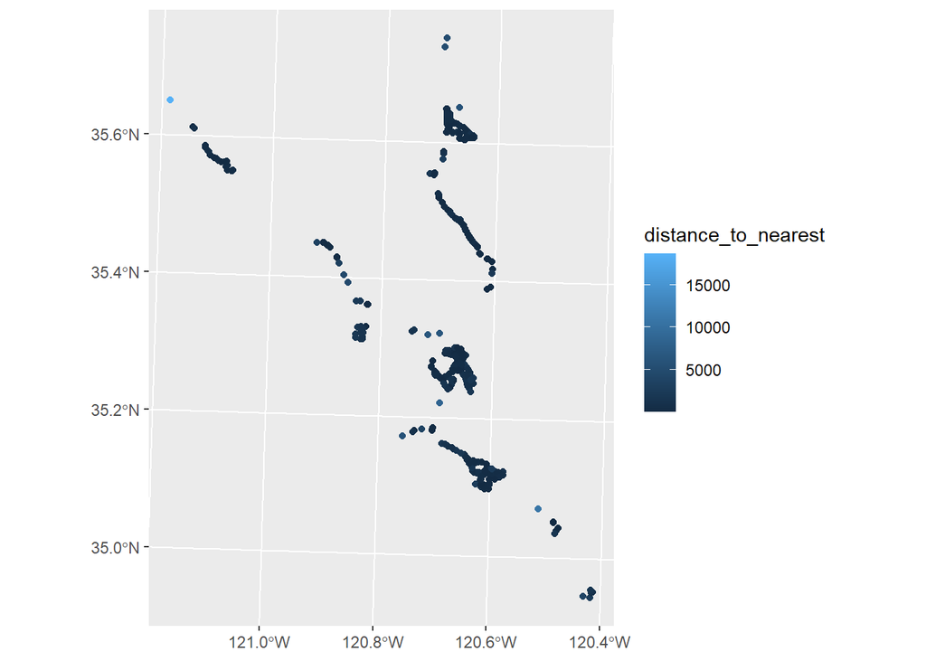

```r
ggplot(stops_st_plane) +
  geom_sf(aes(color = distance_to_nearest),
          size = 1.5)
```